# Datasets

### With 4 gaussians

Let's select the least probable indexes and then display the associated curve and city to see if they may be outliers

```python
Nb_low_proba = 4
```

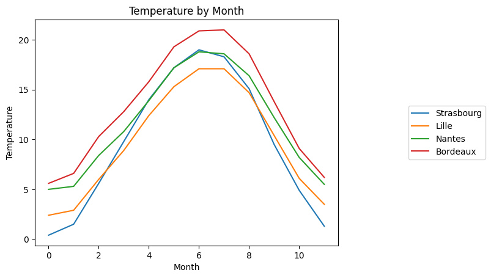

```python
idx_low = np.argsort(temper_scores)[:Nb_low_proba]
display_profiles([temper_data.iloc[i] for i in idx_low], labels=list(temper_data.iloc[idx_low].index))
```

These curves corresponds to real cities and don't seem to contain aberrant values : they're not outliers

```python
temper_data.iloc[idx_low].index
```

```
Index(['Strasbourg', 'Lille', 'Nantes', 'Bordeaux'], dtype='object')
```

## Digits Data

```python
X_digits
```

```
array([[0, 0, 0, ..., 0, 0, 0],
       [0, 0, 0, ..., 0, 0, 0],
       [0, 0, 0, ..., 0, 0, 0],
       ...,
       [0, 0, 0, ..., 0, 0, 0],
       [0, 0, 0, ..., 0, 0, 0],
       [0, 0, 0, ..., 0, 0, 0]], shape=(3000, 784), dtype=uint8)
```

```python
Nb_gaussians_digits = [3, 5, 10]
```

```python
gmm_digits = []
for nb in Nb_gaussians_digits :
    gm_temp = GaussianMixture(nb, covariance_type= 'diag', random_state=42)
    gm_temp.fit(X_digits)
    gmm_digits.append(gm_temp)
```

### With 3 gaussians

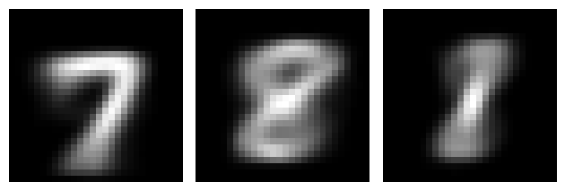

```python
display_images(gmm_digits[0].means_)
```

As for the kmeans centroids, the means of estimated gaussians are a blur and thick version of the numbers (so the gaussian distribution encapsulate better all the typos for each number)

## With other numbers of gaussians

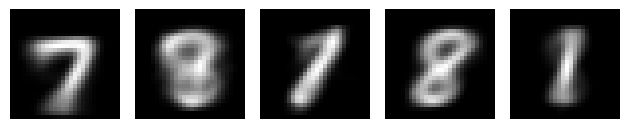

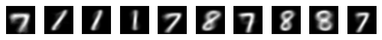

```python
display_images(gmm_digits[1].means_)
display_images(gmm_digits[2].means_)
```

As in the clustering part for more than 3 clusters, the centers seems redundant. This time some centers seems to be a mix between 1 and 7, maybe there is some data group for which there is confusion, let's check the weights.

```python
print("Weights for k = 5 : ", gmm_digits[1].weights_)
print("--------------------------------------------")
print("Weights for k = 10 : ", gmm_digits[2].weights_)
```

```
Weights for k = 5 :  [0.198      0.10166667 0.17733333 0.19466667 0.32833333]
--------------------------------------------
Weights for k = 10 :  [0.04100001 0.06       0.1625262  0.18180713 0.06166667 0.09833378
 0.12233329 0.121      0.05833333 0.09299959]
```

- For the GMM-10, the gaussian looking like a mix of 1 and 7 (the 2nd) has a very small (almost negligible) weight.
- For the GMM-5, the 3rd gaussian has an important weights and the number it is representing is not clear at all. So for a clustering it could lead to interpretability problems, for example we couldn't use the same procedure as for kmeans (grouping clusters for k>3).

We keep the GMM-3 for the rest of this part, as each gaussian distribution corresponds to one of the three numbers represented within the data

## Other covariance types

```python
gmm_digits_covs = []
types_covs = ['full', 'tied', 'spherical']
gmm_digits_covs.append(gmm_digits[0])
for type_cov in types_covs :
    gm_temp = GaussianMixture(3, covariance_type=type_cov, random_state=42)
    gm_temp.fit(X_digits)
    gmm_digits_covs.append(gm_temp)
types_covs = ['diag'] + types_covs
```

```
Gaussians Centers for Covariance Type : diag
```

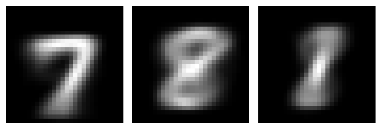

```
Gaussians Centers for Covariance Type : full
```

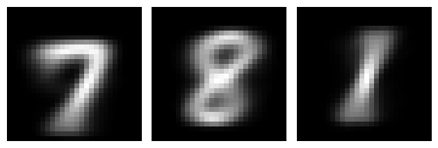

```
Gaussians Centers for Covariance Type : tied
```

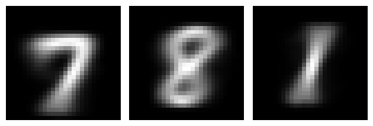

```
Gaussians Centers for Covariance Type : spherical
```

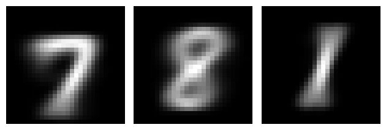

```python
for i in range(len(gmm_digits_covs)) :
    print("Gaussians Centers for Covariance Type : " + types_covs[i])
    display_images(gmm_digits_covs[i].means_)
```

## Outlier detection

```python
gm_digits = gmm_digits[0]
gm_digits
```

```
GaussianMixture(covariance_type='diag', n_components=3, random_state=42)
```

```python
probas_digits = gm_digits.score_samples(X_digits.astype(np.float64))
```

Let's display the samples with the lowest probability

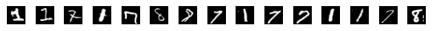

```python
nb_samples = 15

idx_low_d = np.argsort(probas_digits)[:nb_samples]
display_images(X_digits[idx_low_d])
```

Some of them can be considered as outliers as their typo can lead to confusion on the number represented, even from a human point of view

Now let's cluster the data using our GMM-3

```python
gmm_clusters = gm_digits.predict(X_digits.astype(np.float64))
gmm_clusters = labels_translation(gmm_clusters)
```

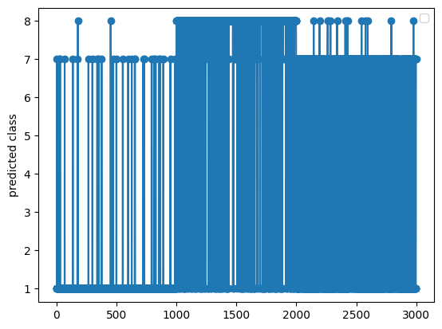

```python
plt.figure()
plt.plot(np.arange(0,len(gmm_clusters)),gmm_clusters, marker = 'o')
plt.ylabel("predicted class")
plt.legend()
plt.show()
```

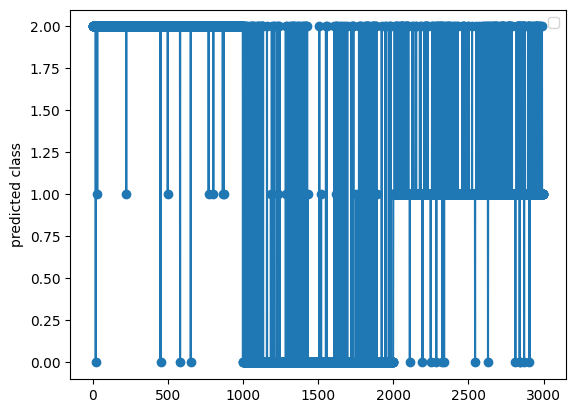

```python
plt.figure()
plt.plot(np.arange(0,len(labels_digits)),labels_digits, marker = 'o')
plt.ylabel("predicted class")
plt.legend()
plt.show()
```

At first look the GMM clustering seems to lead to less accuracy regarding data's labels. Here k is fixed : k = 3

```python
scores = {}
rand_score_digits = metrics.rand_score
adjusted_rand_score_digits = metrics.adjusted_rand_score

s_temp = []
s_temp.append(rand_score_digits(labels_digits_GT, labels_digits))
s_temp.append(adjusted_rand_score_digits(labels_digits_GT, labels_digits))
scores['kmeans'] = s_temp

for i in range(len(gmm_digits_covs)):
    clusters_temp = gmm_digits_covs[i].predict(X_digits.astype(np.float64))
    s_temp = []
    s_temp.append(rand_score_digits(labels_digits_GT, clusters_temp))
    s_temp.append(adjusted_rand_score_digits(labels_digits_GT, clusters_temp))
    scores[f'gmm ({gmm_digits_covs[i].covariance_type} covariance)'] = s_temp

res = pd.DataFrame(scores, index = ['random score', 'adjusted random score'])
res
```

|  | kmeans | gmm (diag covariance) | gmm (full covariance) | gmm (tied covariance) | gmm (spherical covariance) |
| --- | --- | --- | --- | --- | --- |
| random score | 0.885117 | 0.740756 | 0.863577 | 0.898686 | 0.903653 |
| adjusted random score | 0.743111 | 0.441323 | 0.696216 | 0.772979 | 0.783577 |

We can observe that depending on the type of covariance choosed the results can be different.

- For diagonal and Full covariance GMM is less performant than kmeans for clustering.
- For tied and spherical covariance GMM is better than kmeans.

These results can be explained by the fact that the Gaussian Mixture using a multi dimensional covariance matrix while the kmeans only relies on the mean of created groups, especially since the data has quite a high dimensionality.

We can guess that a purely diagonal matrix is too far from the reality in matters of differences between typos for a number, but it is curious that the full covariance leads to less good results than the kmeans (and even than the spherical and tied covariance that have more constraints).

Indeed the random score can't really detect overfitting as it only compares how the clusters fit the fitting data. Maybe this strange results comes from the parameters of the random score or of the optimization of the covariance matrix.

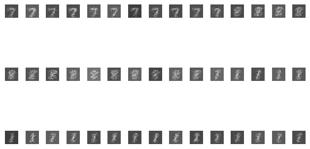

```python
## Data Generation

X_digits_gmm = gm_digits.sample(45)
display_images(X_digits_gmm[0])
```

They don't really look like real numbers : white points less concentrated --> variance too high maybe

# Dimensionality Reduction

```python
from sklearn.decomposition import PCA
from sklearn.manifold import TSNE
```

## Temperature Data

### Principal Component Analysis

```python
temper_data.shape
```

```
(15, 12)
```

```python
cov_temp = np.cov(temper_data.T)
cov_temp.shape
```

```
(12, 12)
```

```python
## Define a function to plot covariance matrices as an image :
def display_cov(cov_matrix, data_title) :
    plt.imshow(cov_matrix)
    plt.title("Covariance Matrix of " + data_title)
    plt.colorbar()
```

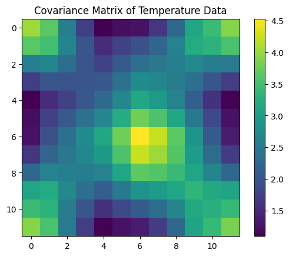

```python
plt.figure()
display_cov(cov_temp, "Temperature Data")
plt.show()
```

Here the features are the average temperature at each month. We can observe that the temperature at summer and winter monthes has a stronger variance than the temperature in autumn or spring. Also because the variance increases in these monthes the covariance between near monthes is also stronger, and we have strong covariance between monthes 1 and 12 because the data has a cyclic evolution with period 12.

```python
pca_temper = PCA(random_state=42)
pca_temper.fit(temper_data)
```

```
PCA(random_state=42)
```

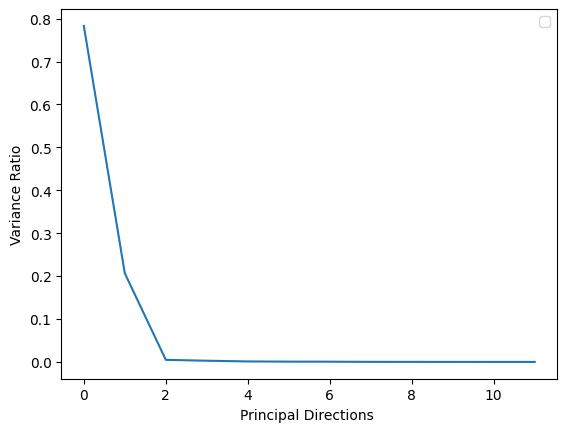

```python
plt.figure()
plt.plot(pca_temper.explained_variance_ratio_)
plt.xlabel("Principal Directions ")
plt.ylabel("Variance Ratio")
plt.legend()
plt.show()
```

```python
pca_temper.explained_variance_ratio_[:2].sum()
```

```
np.float64(0.9896802035903165)
```

We can consider that except the two first components all of them have a negligible impact, and so we can fix the number of components at 2 (we keep 99% of the information).

```python
pca_temper_2 = PCA(2, random_state=42)
transformed_temper_data = pca_temper_2.fit_transform(temper_data)
```

```python
temper_villes
```

```
array(['Bordeaux', 'Brest', 'Clermont-Ferrand', 'Grenoble', 'Lille',
       'Lyon', 'Marseille', 'Montpellier', 'Nantes', 'Nice', 'Paris',
       'Rennes', 'Strasbourg', 'Toulouse', 'Vichy'], dtype='<U16')
```

```python
transformed_temper_data[:,1]
```

```
array([ 0.26531184,  7.52111152, -1.11577501, -3.13861729,  1.13343576,
       -3.27964904, -1.60519291, -0.90701735,  2.10198083,  1.36465031,
       -0.15755765,  3.09546059, -3.82428559, -0.35018275, -1.10367325])
```

```python
def display_transformed_temper(transformed_temper_data, temper_villes = temper_villes) :
    plt.scatter(transformed_temper_data[:, 0], transformed_temper_data[:, 1])
    for i in range(len(temper_villes)) :
        plt.text(transformed_temper_data[i][0], transformed_temper_data[i][1], temper_villes[i])
```

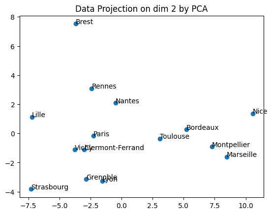

```python
plt.figure()
display_transformed_temper(transformed_temper_data)
plt.title("Data Projection on dim 2 by PCA")
plt.show()
```

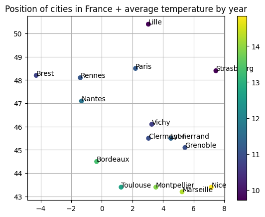

```python
display_cities(temper_mean)
```

The 2D PCA representation and the position of cities relatively to others kind of look like their geographical position, although there is some differences.

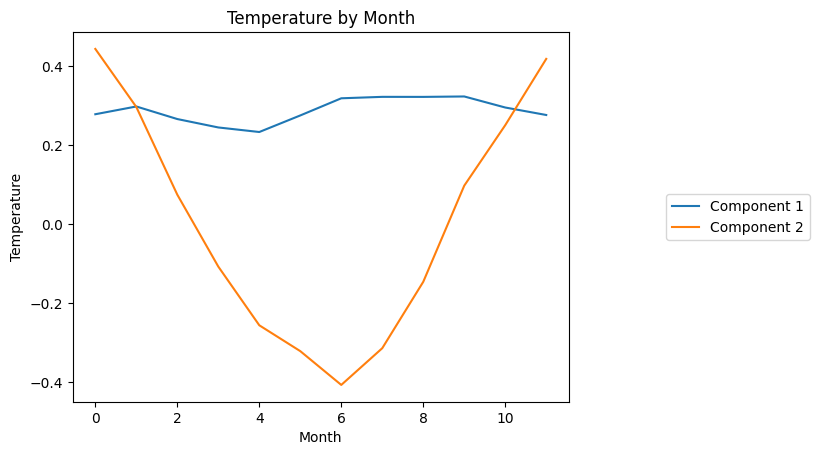

```python
display_profiles(pca_temper_2.components_, labels = ['Component 1', 'Component 2'])
```

Now let's reconsititute the data via PCAs of different subspace sizes

```python
nb_compos = [2, 3, 4, 5, 9, None]
pcas = []
```

```python
for n in nb_compos :
    pca_temp = PCA(n, random_state = 42)
    pca_temp.fit(temper_data)
    pcas.append(pca_temp)
```

```python
temper_data_gen_pca = {}

for i in range(len(nb_compos)) :
    pca_temp = pcas[i]
    pca_gen = pca_temp.inverse_transform(pca_temp.transform(temper_data))
    temper_data_gen_pca[nb_compos[i]] = pca_gen
```

```python
from cycler import cycler
```

```python
def display_reconsitution(temper_data_gen_pca, nb_comp, nb_curves = 3, cols = temper_data.columns) :
    fig, axs = plt.subplots(2,3, figsize = (20,12))
    for i in range(len(nb_comp)) :

        for j in range(nb_curves) :
            axs[i//3, i%3].plot(np.array(temper_data)[j], label = temper_villes[j])
            """
            axs[i//3, i%3].set_xlabel("Monthes")
            axs[i//3, i%3].set_ylabel("Temperature")
            axs[i//3, i%3].set_title(f"K = {nb_compos[i]}")
            """
        axs[i//3, i%3].set_prop_cycle(None)
        for j in range(nb_curves) :
            axs[i//3, i%3].plot(temper_data_gen_pca[nb_comp[i]][j], linestyle = '--', label = temper_villes[j] + " reconstitued from PCA")
            axs[i//3, i%3].set_xlabel("Monthes")
            axs[i//3, i%3].set_ylabel("Temperature")
            axs[i//3, i%3].set_title(f"K = {nb_comp[i]}")
            axs[i//3, i%3].legend()

    plt.suptitle(f"""Temperature by Month Reconstitued from PCA with Different Values of K""")
```

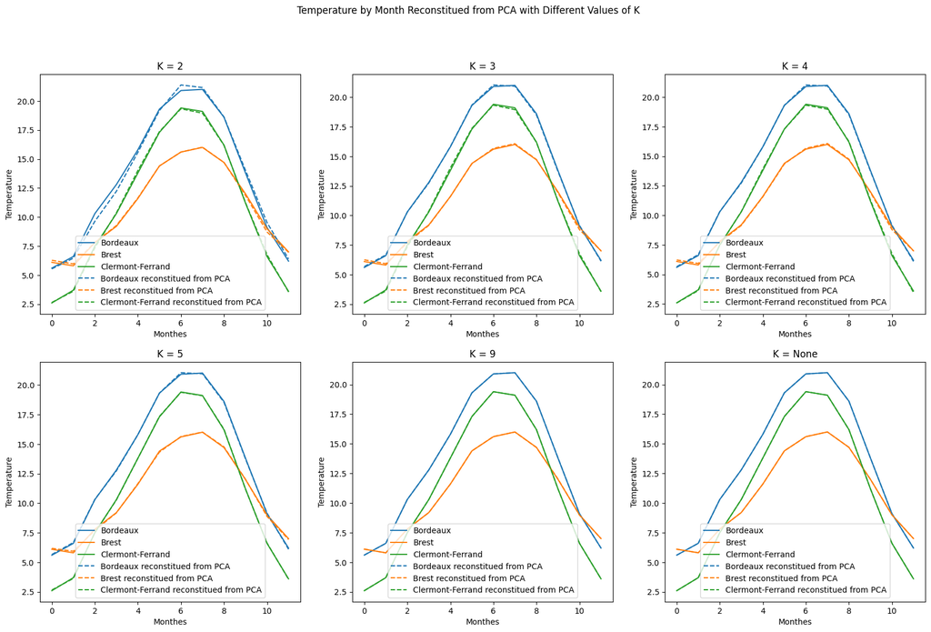

```python
display_reconsitution(temper_data_gen_pca, nb_compos)
plt.show()
```

Even if the reconsititution from a 2D PCA can be precise enough, increasing the number of components allows to get perfectly fitted reconstituted curves (from 9 components).

### TSNE

```python
tsne_temper = TSNE(2, random_state= 42, perplexity= 14.9)
temper_data_tsne = tsne_temper.fit_transform(temper_data)
temper_data_tsne
```

```
array([[  93.1462   ,   36.312756 ],
       [   7.001029 ,  -43.78338  ],
       [ -62.799877 ,   88.19337  ],
       [   8.829185 , -104.6579   ],
       [  27.90576  ,   40.065514 ],
       [  62.866756 ,   90.92373  ],
       [ -24.387554 ,   41.30884  ],
       [ 105.6163   ,  -24.802803 ],
       [ -47.96953  ,  -75.06948  ],
       [  64.18341  ,  -71.82015  ],
       [  45.788857 ,   -8.571444 ],
       [ -32.6648   ,  -10.052712 ],
       [ -91.714775 ,  -31.934933 ],
       [   0.5150905,  100.16387  ],
       [ -86.72902  ,   29.176273 ]], dtype=float32)
```

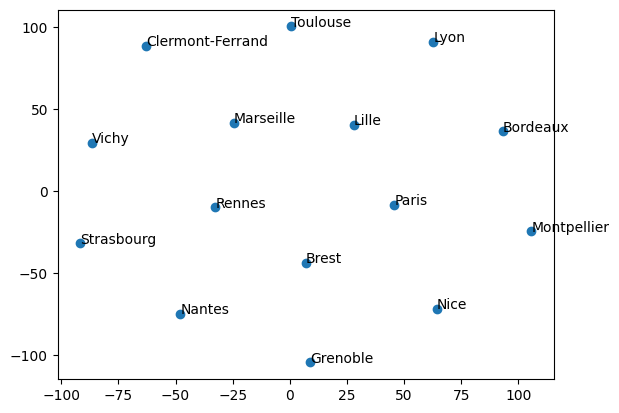

```python
plt.figure()
display_transformed_temper(temper_data_tsne)
plt.show()
```

These results don't seem to represent the any geographical or temperature schemes. Let's try for different values of perplexity :

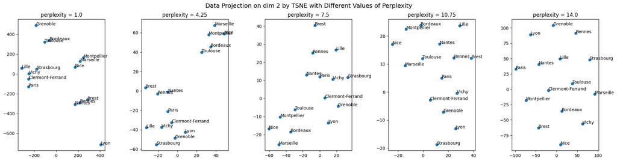

```python
perplex = np.linspace(1, 14, 5)

datas_tsne = []

for p in perplex :
    tsne_temper = TSNE(2, random_state= 42, perplexity= p)
    temper_data_tsne = tsne_temper.fit_transform(temper_data)
    datas_tsne.append(temper_data_tsne)

fig, axs = plt.subplots(1,5, figsize = (20,5))

for i in range(len(datas_tsne)) :
    data = datas_tsne[i]
    axs[i].scatter(data[:, 0], data[:, 1])
    axs[i].set_title(f"perplexity = {perplex[i]}")
    for j in range(len(temper_villes)) :
        axs[i].text(data[j][0], data[j][1], temper_villes[j])

plt.tight_layout()
plt.suptitle("Data Projection on dim 2 by TSNE with Different Values of Perplexity", y = 1.03, fontsize = 14)
plt.show()
```

- Low perplexity : clear separation by regions. Groups of cities are created, corresponding to geographical groups, but the position of each group relatively to each other don't seem to be geographically representative.
- High perplexity : distance between cities seems to be unified.

## Digits Data

### PCA

#### Covariance Matrix Analysis

```python
n_features_digits = len(X_digits[0])
```

```python
cov_digits = np.cov(X_digits.T)
cov_digits
```

```
array([[0., 0., 0., ..., 0., 0., 0.],
       [0., 0., 0., ..., 0., 0., 0.],
       [0., 0., 0., ..., 0., 0., 0.],
       ...,
       [0., 0., 0., ..., 0., 0., 0.],
       [0., 0., 0., ..., 0., 0., 0.],
       [0., 0., 0., ..., 0., 0., 0.]], shape=(784, 784))
```

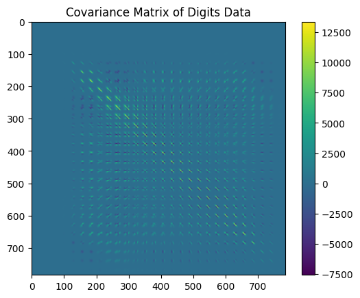

```python
plt.figure()
display_cov(cov_digits, "Digits Data")
plt.show()
```

```python
np.max(cov_temp)
```

```
np.float64(4.532380952380951)
```

The data at the origin of this covariance matrix is a flattened version of the 28*28 images. From this image we can observe that border pixels are all uncorrelated and that the correlated pixels are concentrated at the center of the image. We can observe that the absolute value of these center pixels on the x axis is progressively increases as y increases and we get at the center of the images then proceeds to diminish until it gets to a constant value of 0.

Each apparent sub-matrix corresponds to the covariance of a line with another (characterized by their position on the y axis). Their form vary but represent a coherent evolution according to their position on the matrix. For example the pixels from the lines 4 to 13 (top of the image), seems to be strongly correlated

Let's observe more precisely the covariance of pixels on one line of the images :

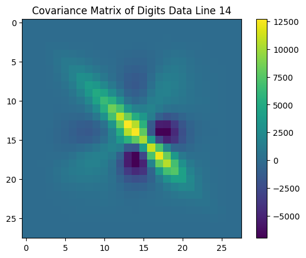

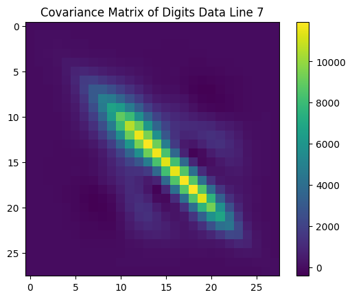

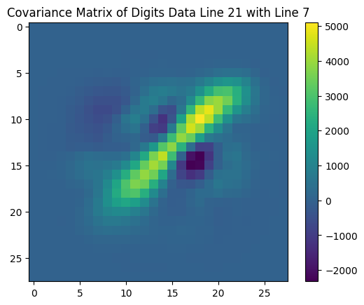

```python
## Covariance of one line with itself

plt.figure()
display_cov(cov_digits[n_features_digits//2 : n_features_digits//2 + 28, n_features_digits//2 : n_features_digits//2 + 28], "Digits Data Line 14")
plt.show()

plt.figure()
display_cov(cov_digits[n_features_digits//4 : n_features_digits//4 + 28, n_features_digits//4 : n_features_digits//4 + 28], "Digits Data Line 7")
plt.show()

## Covariance of two different lines

plt.figure()
display_cov(cov_digits[3*n_features_digits//4 : 3*n_features_digits//4 + 28, n_features_digits//4 : n_features_digits//4 + 28], "Digits Data Line 21 with Line 7")
plt.show()
```

- In the same line, pixels seems to have a strong covariance with their neighbors. It can be explained by the fact that each drawed number has a thickeness of a few pixels. It is especially the case at the top of the numbers, 1, 7, and 8 have a more or less large band at their top (in average it's large). Indeed we can observe this strong neighbor covariance for the top lines on the global covariance matrix.
- In different lines, position on the x axis seems to have a strong covariance with their symetric according to the middle point of the image.

We can also observe this symmetry on the global covariance matrix : as y increase the 'vector' drawed by the pixels with strong covariance progressively roatate :

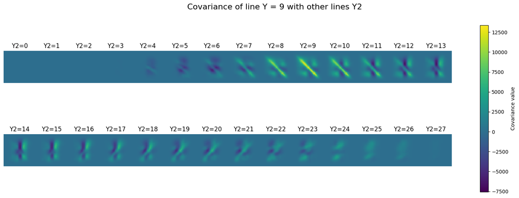

```python
## For example if we look at the covariance of the line Y = 9 with all the other lines :
Y = 9
img_size = 28

fig, axs = plt.subplots(2,14, figsize = (20, 6))

vmin = cov_digits.min()
vmax = cov_digits.max()

ims = []

for i in range(n_features_digits//img_size):
    im = axs[i//14, i%14].imshow(cov_digits[img_size * Y : img_size * (Y+1), img_size * i : img_size * (i+1)], vmin = vmin, vmax = vmax)
    axs[i//14, i%14].axis('off')
    axs[i//14, i%14].set_title(f"Y2={i}")
    ims.append(im)

plt.subplots_adjust(wspace=0, hspace=0)
cbar = fig.colorbar(ims[0], ax=axs)
cbar.set_label("Covariance value")

fig.suptitle(f"Covariance of line Y = {Y} with other lines Y2", fontsize = 16)
plt.show()
```

This central symmetry can be explained by the form of the numbers 1, 7 and 8 : 8 is completely central symmetric, 1 is almost, 7 is not but contains more or less a diagonal. In average, these numbers admits approximatively a central symmetry.

#### PCA

```python
pca_digits = PCA(random_state=42)
pca_digits.fit(X_digits)
```

```
PCA(random_state=42)
```

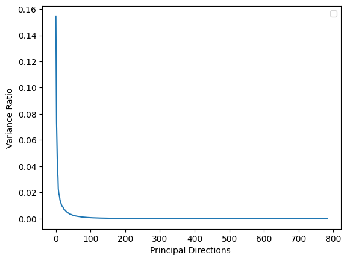

```python
## Display Explained Variance Ratio

plt.figure()
plt.plot(pca_digits.explained_variance_ratio_)
plt.xlabel("Principal Directions ")
plt.ylabel("Variance Ratio")
plt.legend()
plt.show()
```

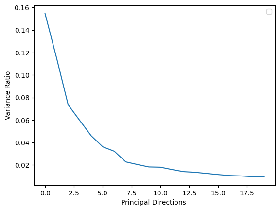

```python
## Display Explained Variance Ratio

plt.figure()
plt.plot(pca_digits.explained_variance_ratio_[:20])
plt.xlabel("Principal Directions ")
plt.ylabel("Variance Ratio")
plt.legend()
plt.show()
```

```python
pca_digits.explained_variance_ratio_[:2].sum()
```

```
np.float64(0.2695057794431238)
```

The quantity of information present on each dimension diminishes exponentially, but if we limit the number of components to 2 the quantity of info retained is 27%. According to these numbers the PCA with two components seem much less efficient on the digits data than on the temperature data

```python
pca_digits_2 = PCA(2, random_state=42)
X_digits_pca_2 = pca_digits_2.fit_transform(X_digits)
X_digits_pca_2
```

```
array([[ 970.11884733,  185.68029991],
       [ 210.37122024, -553.13156579],
       [ 301.25509461, -753.20075765],
       ...,
       [ 105.03441629,  190.8572144 ],
       [-616.49810385,  820.0976308 ],
       [-613.73910043,  790.44295574]], shape=(3000, 2))
```

```python
X_digits_pca_2[:, 1]
```

```
array([ 185.68029991, -553.13156579, -753.20075765, ...,  190.8572144 ,
        820.0976308 ,  790.44295574], shape=(3000,))
```

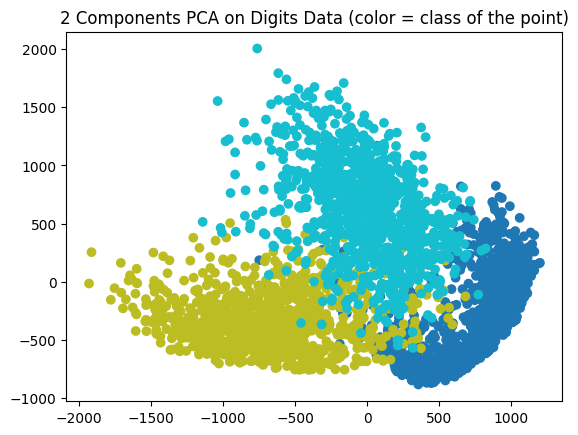

```python
colormap = ['blue', 'orange', 'green']

plt.figure()
plt.scatter(X_digits_pca_2[:, 0], X_digits_pca_2[:, 1], c = labels_digits_GT, cmap = 'tab10')
plt.title("2 Components PCA on Digits Data (color = class of the point)")
plt.show()
```

We can observe that the points seem clustered by class, but these clusters are not separated enough to differenciate them without color markers.

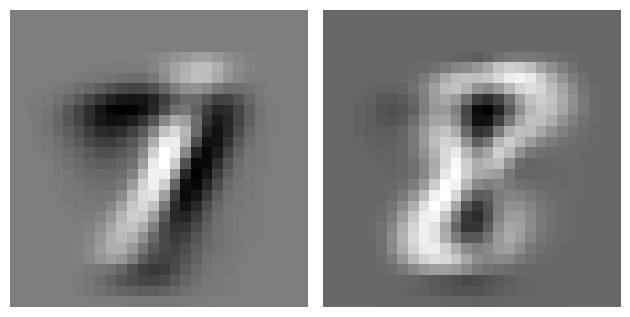

```python
digits_pca_components = pca_digits_2.components_
plt.figure()
display_images(digits_pca_components)
plt.show()
```

Each of the components seems to have the effect of drawing a specfic number while deleting an other

- Moving along the first direction draws a 1 and delete a 7
- Moving along the second direction draws an 8 and delete a 1

```python
c = 2
nb_compos_digits = []

while c< n_features_digits:
    nb_compos_digits.append(c)
    c*=2
nb_compos_digits.append(None)
nb_compos_digits
```

```
[2, 4, 8, 16, 32, 64, 128, 256, 512, None]
```

```python
recon_digits = []
for n in nb_compos_digits :
    pca_temp = PCA(n, random_state=42)
    data_temp = pca_temp.fit_transform(X_digits)
    r = pca_temp.inverse_transform(data_temp)
    recon_digits.append(r)
vmin = np.array(recon_digits).min()
vmax = np.array(recon_digits).max()
```

```python
nb_samples = 10
random_index = np.random.randint(0, 3000, 10)
```

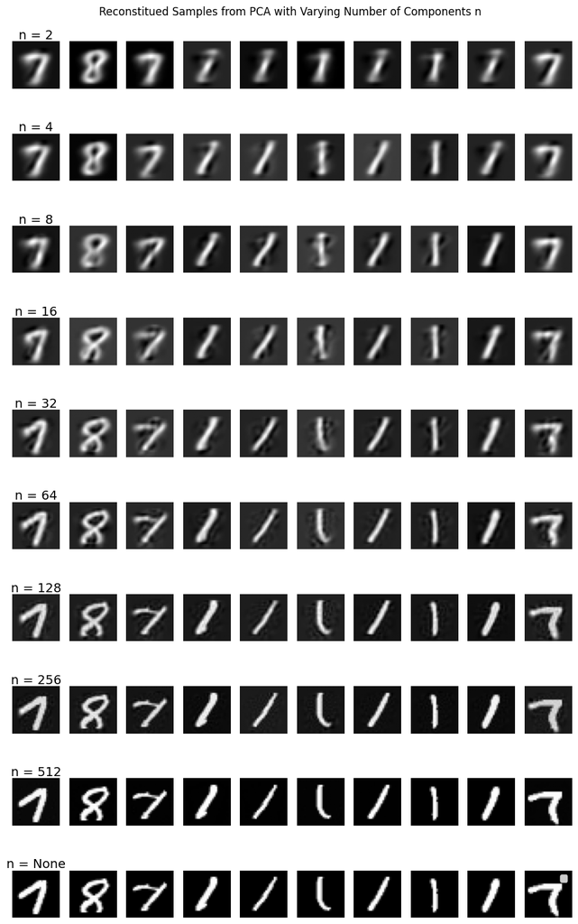

```python
fig, axs = plt.subplots(nb_samples, len(nb_compos_digits), figsize = (9,15))
for i in range(len(recon_digits)) :
    r = recon_digits[i]
    for j in range(nb_samples):
        axs[i,j].imshow(r[random_index[j]].reshape((28,28)), cmap = 'gray')
        axs[i,j].axis('off')
    axs[i, 0].set_title(f"n = {nb_compos_digits[i]}", fontsize=14, va='center')

plt.legend()
plt.suptitle("Reconstitued Samples from PCA with Varying Number of Components n ")
plt.tight_layout()

plt.show()
```

### TSNE

```python
tsne_digits = TSNE(2, random_state=42)
X_digits_tsne = tsne_digits.fit_transform(X_digits)
```

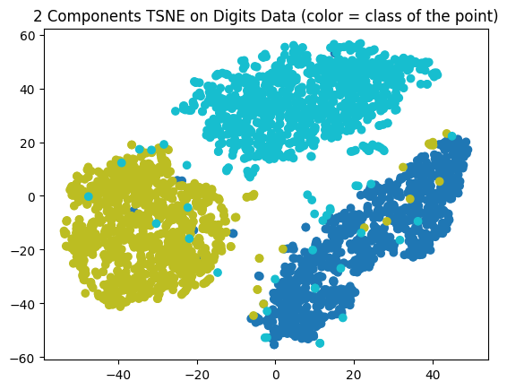

```python
colormap = ['blue', 'orange', 'green']

plt.figure()
plt.scatter(X_digits_tsne[:, 0], X_digits_tsne[:, 1], c = labels_digits_GT, cmap = 'tab10')
plt.title("2 Components TSNE on Digits Data (color = class of the point)")
plt.show()
```

The data seems approximatively well separated according to the class, but some errors are still present

```python
ppl = np.array([5, 10, 15, 30, 50, 100, 250, 500, 1000, 2000])
X_digits_tsnes = []

for p in ppl :
    tsne_temp = TSNE(2, random_state=42, perplexity= p)
    X_digits_tsnes.append(tsne_temp.fit_transform(X_digits))
```

```python
X_digits_tsnes[i][:,0]
```

```
array([ 0.9259401 ,  1.0297534 ,  0.8080825 , ..., -0.46065307,
       -2.1332216 , -1.6222111 ], shape=(3000,), dtype=float32)
```

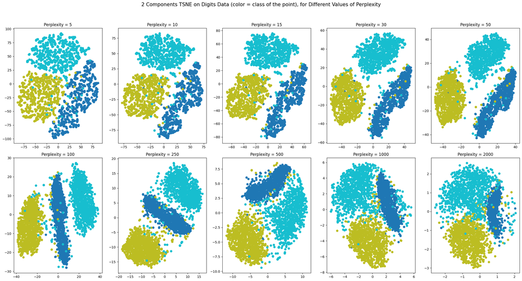

```python
fig, axs = plt.subplots(2,5, figsize = (22,12))

for i in range(len(ppl)) :

    data = X_digits_tsnes[i]
    a = axs[i//5,i%5]
    a.scatter(data[:, 0], data[:, 1], c = labels_digits_GT, cmap = 'tab10')
    a.set_title(f"Perplexity = {ppl[i]}")

plt.suptitle(f"2 Components TSNE on Digits Data (color = class of the point), for Different Values of Perplexity", fontsize = 15)
plt.tight_layout(rect=[0, 0, 1, 0.95])
plt.show()
```

As we could expect, the TSNE is more adapted than PCA to discriminate drawed numbers, as their line is not linear (notably the 8). For a particulary low or high perplexity (near 0 or 3000) the clusters are not clearly separated, the data from different class is even mixed up for very high values.